# Introduction to Statistics

Lecture 1 - LAS

Don van den Bergh

2026-08-24

# Introduction

## Who are we?

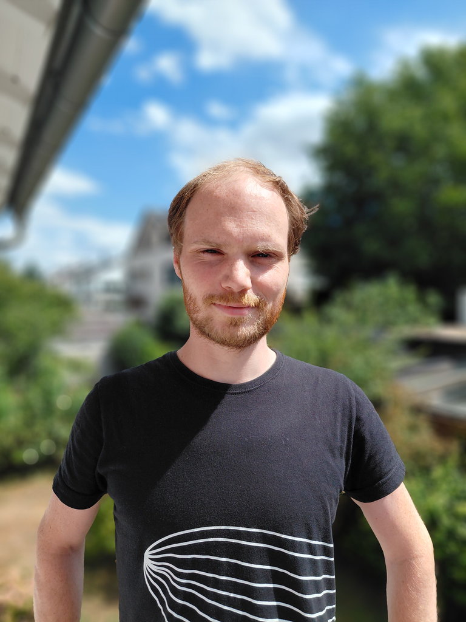

Don van den Bergh

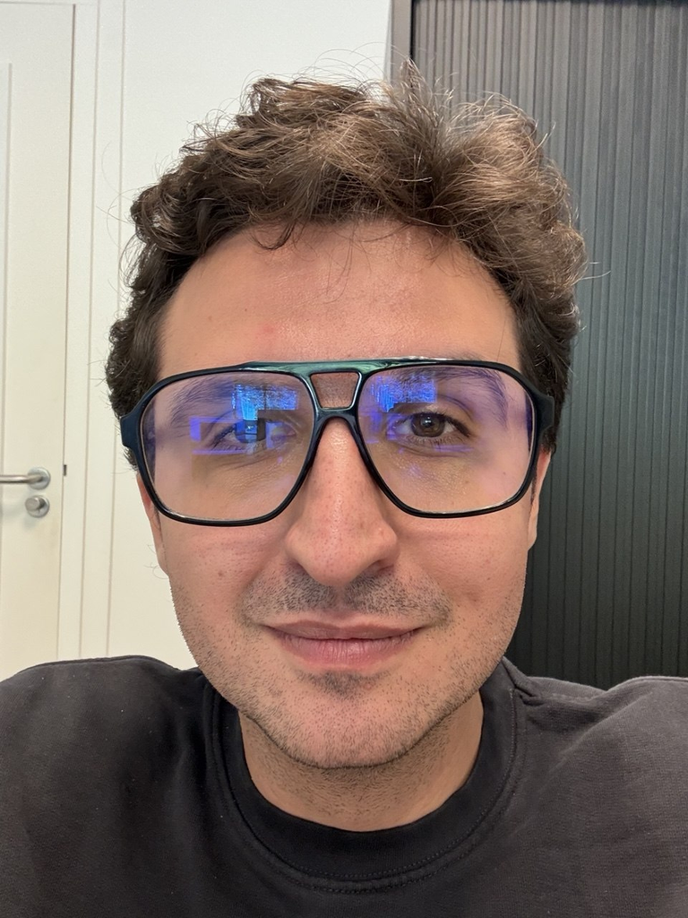

Amirali Rezazadeh

## Why statistics?

You grew up in the “digital age”. There is data about your entire life…

## And everybody wants your data

[figure not shown]

[figure not shown]

[figure not shown]

[figure not shown]

## What can you do with data?

- Data literacy is increasingly important in many jobs
- You can get insights from data to
  - Better understand social life
  - Predict sales and optimize marketing
  - Explore what activity in the brain is associated with observed behavior
- Data analysis is one of the most marketable concrete skills we teach at university

# Course Outline

## Overview

- What can you expect for this course?
  - 14 lectures
  - 10 lab sessions
- What will the exam look like?
  - Multiple choice exam (1-10)
  - SPSS test (Pass/ Fail)
- What more do we offer you?
  - Additional video lectures
  - Short lecture quizzes
  - Midterm quiz
  - Practice exams online
  - Practice workbook online

## Learning Goals

- Compute and interpret commonly used descriptive statistics
- Recognize different probability distributions
- Explain the essential aspects of null-hypothesis significance testing
- Conduct statistical tests
- Choose the appropriate analysis technique for answering a specific research problem
- Use SPSS
- Draw valid conclusions from the results of empirical data analyses given specific research questions envisaged

## Grading

- Two Exams (each 30%): on 15-10-2026 and 10-12-2026
- Two Assignments (Portfolio; 40%): due 13-10-2026 and 14-12-2026
- Combined resit for both exams (60%): 06-01-2027

## Typical Schedule

- Monday: Lecture (either 10:45 - 12:30 or 16:45 - 18:30)
- Thursday/ Friday: Tutorial (12:45 - 14:30 or 14:45 - 16:30)
  - You can work on the weekly quizzes and the assignments

**Note**

Always check TimeEdit for the most up to date information!

## GitBook

See https://cjvanlissa.github.io/stats12/

- [Self study questions](https://cjvanlissa.github.io/stats12/introduction.html#formative-test)
- [Weekly quizzes](https://cjvanlissa.github.io/stats12/introduction.html#tutorial)
- [Assignments](https://cjvanlissa.github.io/stats12/statistics1.html#assignments)

## GitBook – outdated!

All information under course-schedule is outdated.

- Classical lectures
- Dates are all from past year

# Dictionary of Basic Concepts

## Is Life Worth Living?

9 out of 10 adults in the Netherlands think life is worth living

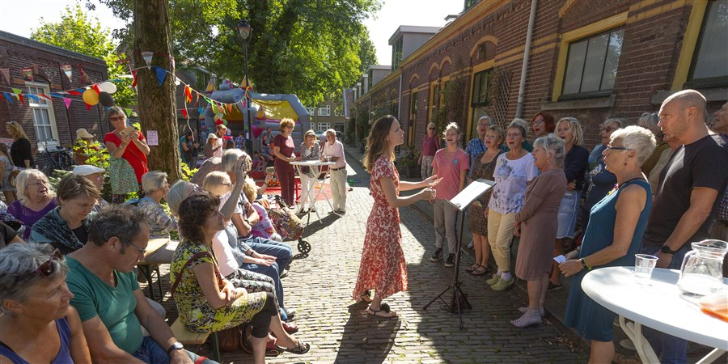

Source: https://www.cbs.nl/nl-nl/nieuws/2026/31/9-op-de-10-volwassenen-vinden-het-leven-de-moeite-waard

## Methods and Statistics

Methods is about the procedures of research:

- What actions do we take to collect good data
- Which participants to include
- How to measure what we want to measure
- How to design studies that are suitable for answering our research questions

Methods involve the design of a study or data collection

## Methods and Statistics

Statistics is about analyzing data

- **Descriptive statistics**: describing/summarizing data
- **Inferential statistics**: Making best guesses about the population from a smaller sample
- **Statistical modeling**: Representing a theory mathematically
- Predicting important outcomes (sales, well-being, neurological disorders)
- Exploring data to find interesting patterns
- Performing tests to answer theoretical research questions

Statistics are the mathematics behind going from *raw data* to conclusions.

## Tabular Data

Most data in the social sciences is tabular, where each row represents an individual $i$ observation, and each column $j$ represents that individual’s data on several variables:

[figure not shown]

## Example: Items

- I find my life worthwhile.
- I feel that I contribute something to society.
- I feel useful.
- I am able to do the things that I want to do and consider important in my life.
- How important are social contacts and relationships in your life?
- How important is personal development to you?
- How hopeful are you about the future? (1 - 10)

## Example: Tabular Data

| id | age | age_group | volunteer | weekly_social_contact | worthwhile | contribution | social_contacts_important | personal_development_important | autonomy | useful | hopeful |
| --- | --- | --- | --- | --- | --- | --- | --- | --- | --- | --- | --- |
| 1 | 27 | 25 - 35 | False | True | Strongly Agree | Agree | Agree | Agree | Strongly Agree | Agree | Undecided |
| 2 | 70 | 65 - 75 | False | True | Strongly Agree | Agree | Strongly Agree | Agree | Strongly Agree | Strongly Agree | Agree |
| 3 | 30 | 25 - 35 | True | True | Strongly Agree | Agree | Strongly Agree | Agree | Strongly Agree | Strongly Agree | Strongly Agree |
| 4 | 42 | 35 - 45 | False | True | Strongly Agree | Strongly Agree | Agree | Strongly Agree | Strongly Agree | Strongly Agree | Strongly Agree |
| 5 | 78 | above 75 | True | True | Strongly Agree | Agree | Agree | Agree | Strongly Agree | Strongly Agree | Agree |
| 6 | 54 | 45 - 55 | True | True | Agree | Agree | Agree | Agree | Agree | Agree | Agree |
| 7 | 89 | above 75 | True | False | Strongly Agree | Strongly Agree | Agree | Strongly Agree | Strongly Agree | Strongly Agree | Strongly Agree |
| 8 | 56 | 55 - 65 | False | True | Strongly Agree | Strongly Agree | Agree | Strongly Agree | Strongly Agree | Strongly Agree | Strongly Agree |
| 9 | 21 | 18 - 25 | True | True | Strongly Agree | Strongly Agree | Agree | Strongly Agree | Strongly Agree | Strongly Agree | Agree |
| 10 | 70 | 65 - 75 | True | True | Agree | Agree | Strongly Agree | Strongly Agree | Agree | Agree | Disagree |

[output cut: 20 more lines]

simulated based on the article

## About Observations: Population

- The complete set of objects of interest
  - E.g., all people in NL, all students in this class
- Number of individuals in the population: N
  - N = 17.53 million, N = 75
- The correlation (linear dependence) between language and mathematics ability across all humans on earth
  - $\rho = .3$
- The “true” effect of class attendance on grades in students
  - $\delta = 0.4$

## Population: Example

In the survey on happiness, the CBS interviewed 7,551 participants aged 15 and above.

What is the population?

Adults in the Netherlands / Above 15 year olds.

## About Observations: Sample

What is a sample?

[figure not shown]

[figure not shown]

[figure not shown]

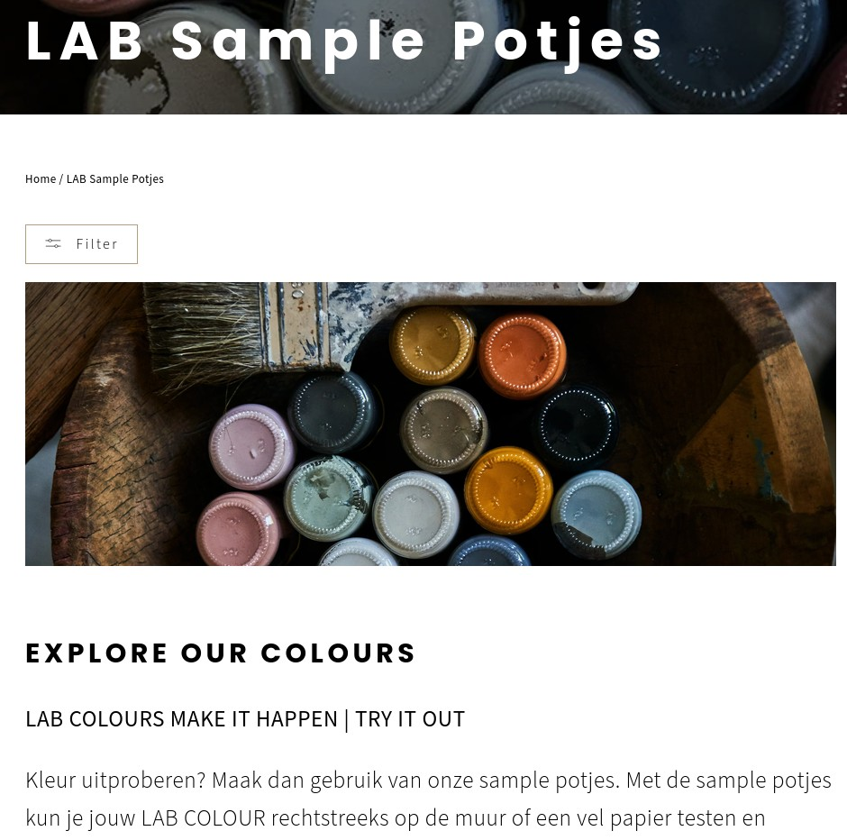

## About Observations: Sample

- Observed part of the population
- Number of observations: *n*
- The correlation (linear dependence) between language and mathematics ability across all pupils measured as part of a study:
  - $r = .25$
- The effect size of class attendance on grades observed at Tilburg University
  - $d = 0.4$

A common pattern is *upper case* or *Greek* symbols ($\sigma$) for the population and *lower case* or *Roman* symbols ($s$) for the sample.

## About Variables: Construct

**Construct:**

- Abstract feature of interest for the population
  - E.g., Short Term Memory, intelligence, perseverance, education

**Operational definition:**

- Concrete measurable representation of the construct
  - E.g., Number of words recalled, the Wechsler Adult Intelligence Scale (WAIS), ability to withstand a tasty treat, highest degree obtained

## About Variables: Variable

**Variable:**

- (Mathematical) placeholder for specific values
- E.g., `WAIS` is a variable representing scores on the WAIS
- You can refer to a variable without (yet) knowing its specific values

**Data:**

- Specific values of a variable
- Example of data: Jen’s score on the variable `WAIS` is 138

## Example

- Construct: Happiness
- Operational definition: “On a scale from 1 to 10, to what extent do you consider yourself a happy person?”
- Variable: `happiness`, taking values 1–10
- Data: respondent 382 answered 8

# Break

See you in ~10 minutes!

# Role of Data in Scientific Research

## Empirical cycle

De Groot (1961)

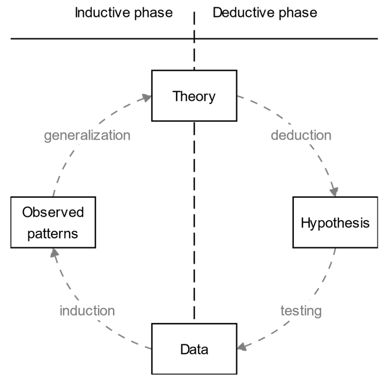

## Relationship between Theory and Empiricism

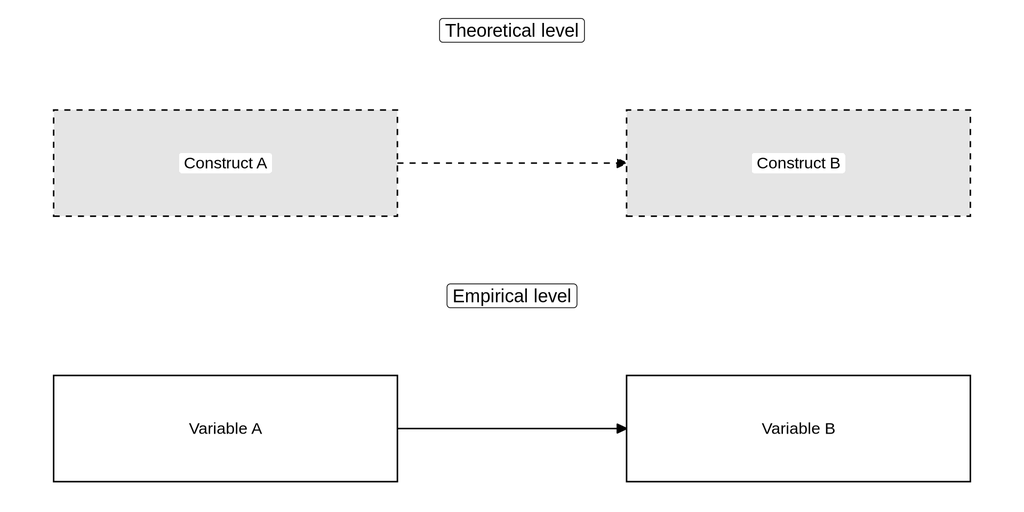

## Relationship between Theory and Empiricism

Theory:

Construct A influences construct B

- E.g., being exposed to war increases depression

Empirical test:

Variable A predicts variable B

- E.g., being deployed (yes/no) predicts scores on the SCL-90 depression questionnaire

## Relationship between Theory and Empiricism

CBS reports that 87.4% of Dutch adults are “happy”. What does “happy” mean?

- CBS classifies a responses as:
  - 7–10: happy
  - 5–6: as neither happy nor unhappy
  - 1–4: unhappy

Note: Happiness is not “answered >6 on this particular question”.

This is just a (necessary) operationalization.

Theory: Having meaningful social relationships makes people happier.

Empirical hypothesis: Respondents who have frequent contact with family/friends report higher happiness scores.

## Sampling Theory

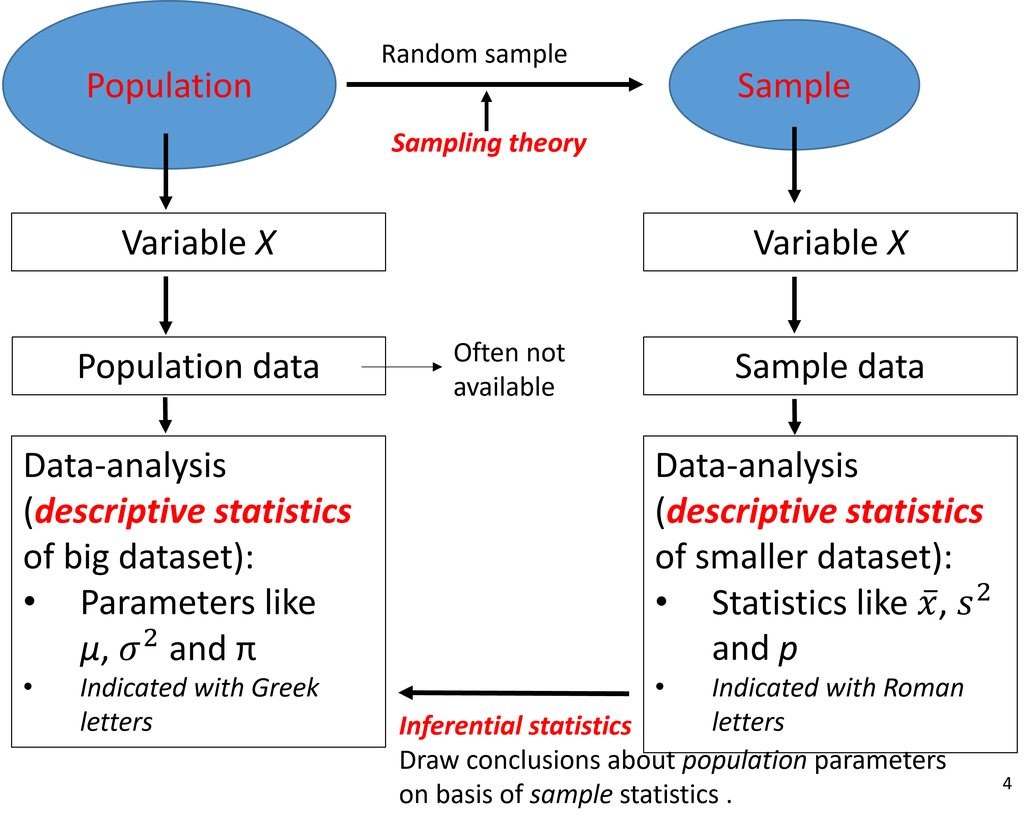

## Samples: Why?

- We want to make a claim about the population
- It is not possible to access the entire population
- We observe a part of the population: the *sample*
- Sample statistics are also our best guess about population parameters
  - Of course, sample statistics are not *equal to* population parameters
  - You will learn ways to express uncertainty about your best guess

## Samples: Why?

- If the sample is *representative* of the population, your best guess will generalize better to the entire population and to new samples
- The best way to get a representative sample is *random sampling*
- Random sample:
  - Every population individual has the same probability of being included

## Non-random samples

- Probability of inclusion unknown to the researcher
- Examples: convenience sampling, snowball sampling, cluster sampling
- Sampling bias
  - E.g., Individuals that are easy to access ave higher probability of being included

## A lot of sampling theory is just *cooking*

- Suppose you want to know if your soup needs more salt.
  - You don’t eat the whole soup, you *sample* it.
  - You stir the soup so to take a *random* sample.
  - If you keep tasting from the spoon while adding salt to the soup, the sample is *non-random*.

# Measurement Level

## NOIR measurement levels

Measurement level: What kind of information is contained in a variable?

Mnemonic: `n o i r` = black in French

Subsequent levels carry incremental information

The measurement level determines what statistics are appropriate. - Example: We cannot compute a mean for gender

## NOIR measurement levels

- `N`ominal
  - Categories; values differ in name only (e.g., majors)
- `O`rdinal
  - Categories; additionally, values have meaningful order (e.g., SES groups, bachelor year 1, 2, 3)
- `I`nterval
  - Numeric; additionally, distance between values is meaningful
  - A step from 1 to 2 is equally large as a step from 2 to 3, or 5 to 6
- `R`atio
  - Numeric; additionally has a meaningful zero-point
  - Because of this, ratios between two values are also meaningful

## Example

- Operational definition of happiness
  - “On a scale from 1 to 10, to what extent do you consider yourself a happy person?”

What measurement level is this?

Ordinal because distances are meaningless. In practice often analyzed as interval (which is suboptimal).

## Interval v Ratio

- Celsius and Fahrenheit are interval scales
- Kelvin is a ratio scale

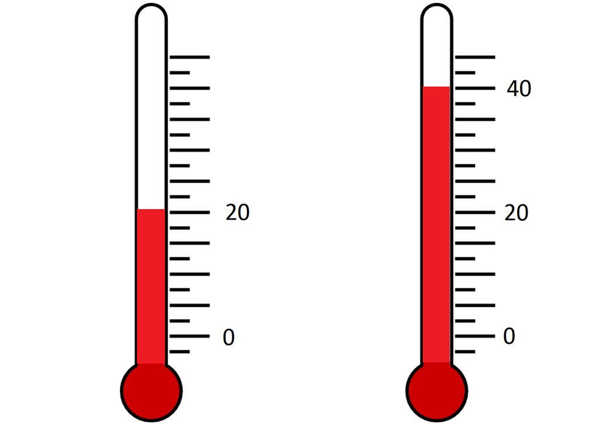

## Interval v Ratio

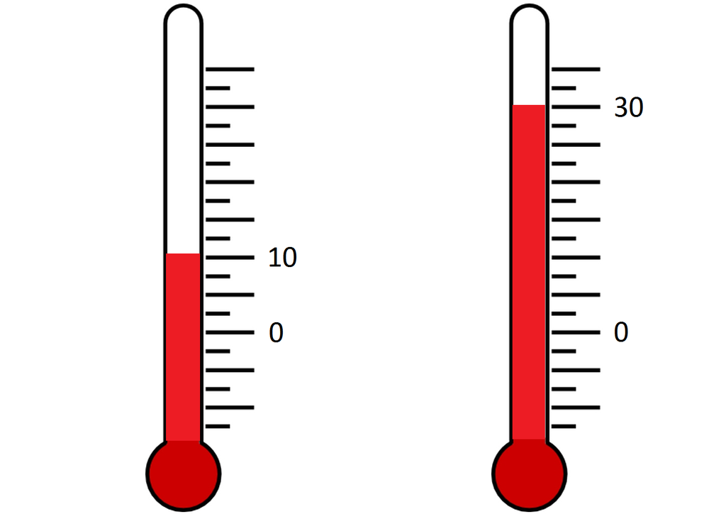

## Measurement level matters

- Measurement level is a property of the construct and of the operational definition
  - Ideally, the measurement level of the construct and its variable are the same
  - E.g., sex assigned at birth: nominal
  - E.g., gender identification: ordinal or continuous
- Measurement level determines what statistics and analyses you can use

## Other common distinctions

- Categorical variables: Nominal, Ordinal
- Continuous variables: Interval, Ratio
- Qualitative variable: Difference in kind, Nominal
- Quantitative variables: Differences in degree; ordinal, interval, ratio

Edge cases:

- Number of children (discrete ratio)
- Political orientation from liberal to conservative (ordinal, but which is higher/lower?)

## Example

What measurement level is age?

- Milliseconds since the big bang?
- Unix time (the number of non-leap seconds that have elapsed since 00:00:00 UTC on 1 January 1970)
- Intervals: 0 - 5, 6 - 10, 11 - 15
- Months
- Generation: Generation X, Millennials, Gen Z, Gen Alpha

It depends on the way it’s measured!

# Descriptive Statistics

## Descriptive Statistics

- Descriptive statistics summarize data across a sample
- You nearly always examine them to get a sense of your dataset
  - E.g., which major is most common among LAS students?
  - How old are my students, on average?
  - How much do the ages of my students vary?
  - What’s the gender distribution?
- Descriptive statistics *may* also be relevant to answer research questions
  - E.g.: When evaluating exam questions: Is the proportion of correct answers on this MC question greater than chance?

## Distributions

| Type of variable | Central tendency | Graph |
| --- | --- | --- |
| Nominal | Frequency distribution | Bar chart |
| Ordinal | (Cumulative) frequency distribution | Bar chart |
| Interval/ratio | (Normal) probability distribution | Histogram, density plot |

## A Nominal Variable

| Major | Frequency | Percent |
| --- | --- | --- |
| BE | 5 | 0.07 |
| CN | 25 | 0.33 |
| SS | 45 | 0.60 |

## Bar Chart

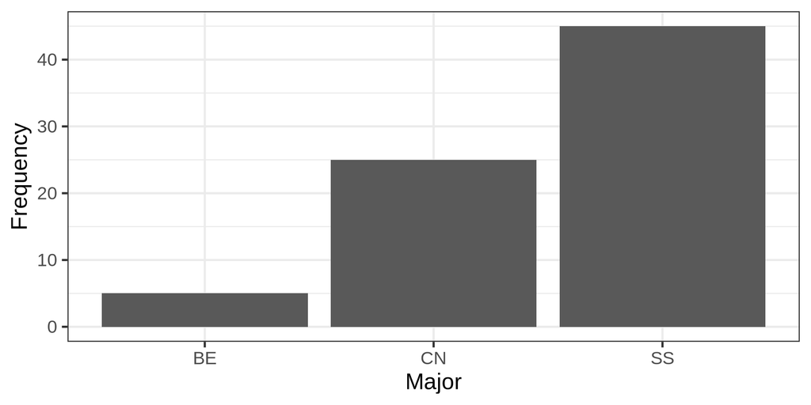

## An Ordinal Variable

| SES | Frequency | Percent | Cumulative |
| --- | --- | --- | --- |
| Low | 32 | 0.43 | 0.43 |
| Medium | 36 | 0.48 | 0.91 |
| High | 7 | 0.09 | 1.00 |

## Bar Chart

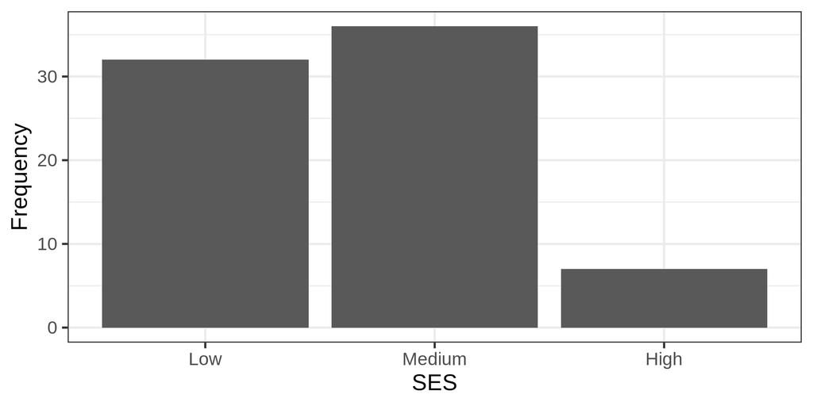

## A Continuous Variable

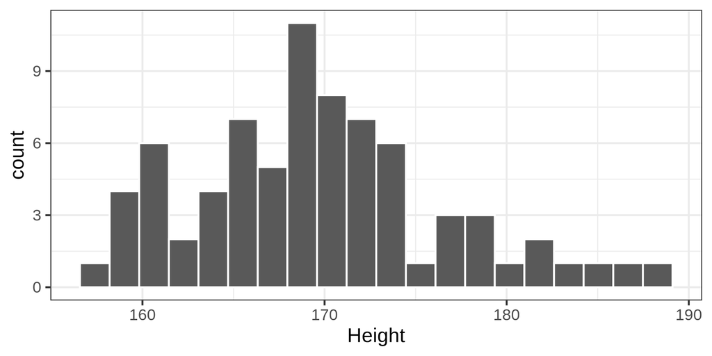

## Measures of Central Tendency

What is the average or most common response?

| Type of measure | Type of variable | Definition |
| --- | --- | --- |
| Mode | Nominal/Ordinal | Most common value |
| Median | Ordinal/Continuous | Middle value/50th percentile |
| Mean | Continuous | Average value |

## Measures of Dispersion

How much variability is there in responses?

| Type of measure | Type of variable | Definition |
| --- | --- | --- |
| Frequency table | Nominal | Count/percentage of responses |
| Range | Ordinal/continuous | Minimum to maximum value |
| Variance | Continuous | Mean squared distance of observations to the mean |

## Calculating the Variance

Variance:

$$S_X^2 = \frac{\sum_{i=1}^n(X_i-\bar{X})^2}{n-1}$$

Units of $S^2$ are squared; if you measured height in meter $m$, $S^2_{height}$ is expressed in $m^2$

Standard deviation (SD): $S_X = \sqrt{S_X^2}$, so the unit is $m$.

For what variables is this meaningful?

Interval and ratio variables.

## Median and Mode for Ordinal Variable

**Median:** middle value

Example 1: ( *n* = unequal): 4, 5, 6, 7, 8, 9, 9 -> median is 7

Example 2: ( *n* = equal): 4, 5, 6, 8, 9, 9 -> median 7 (mean of the two middle values)

**Mode:** Most frequent score; 9 in both examples

## Mean, Median, Mode for Continuous Variable

The average Australian is a millionaire

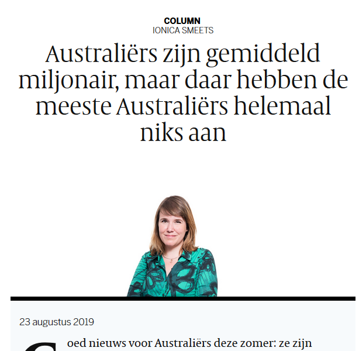

But… most Australians are not!

Source: https://www.volkskrant.nl/columns-opinie/australiers-zijn-gemiddeld-miljonair-maar-daar-hebben-de-meeste-australiers-helemaal-niks-aan~b8aa3fd3

[without paywall](https://archive.ph/wuIQA)

## Skewed Distributions

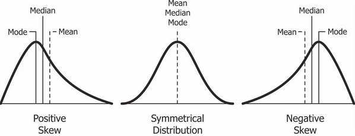

## Mean, variance

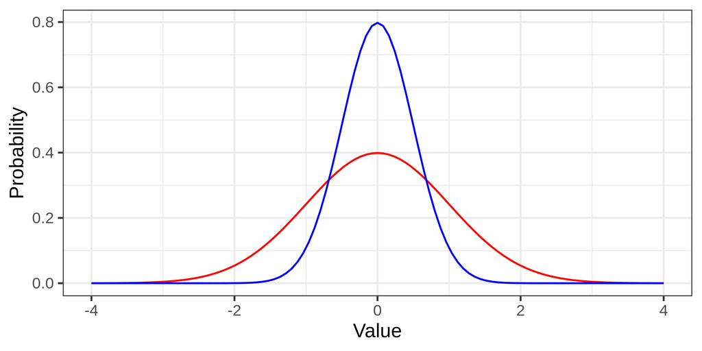

# Bivariate Descriptives

Describing associations

|  | Nominal | Ordinal | Interval/Ratio |
| --- | --- | --- | --- |
| Nominal | Contingency Table | Contingency Table | Contingency table |
| Ordinal |  | Contingency Table Spearman’s correlation | Biserial Correlation |
| Interval/Ratio |  |  | Pearson Correlation Coefficient Scatter plot |

## Contingency table

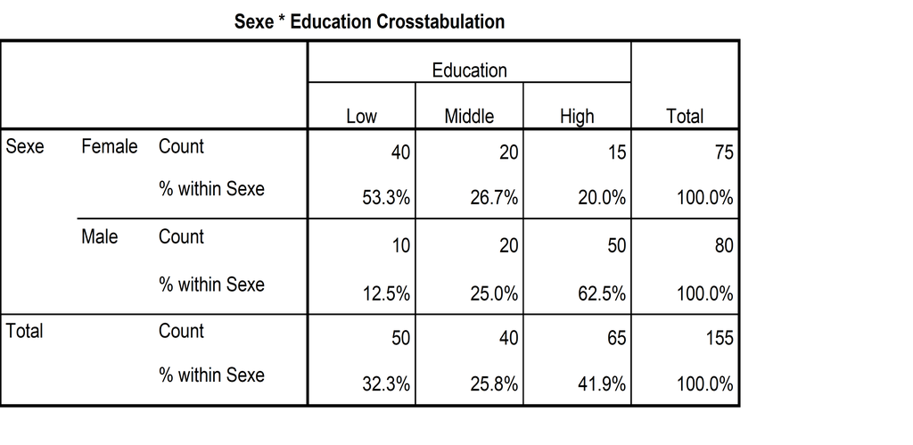

Is there an association between gender and education?

## Correlation

> **Correlation:** A standardized measure of the strength of linear association between two continuous variables.
- Standardized: ranges from $[-1,\, 1]$
- Sample correlation: $r$
- Population correlation: $\rho$
- $r = -1$: Perfect negative association
- $r = 0$: No association
- $r = 1$: Perfect positive association

## Correlations

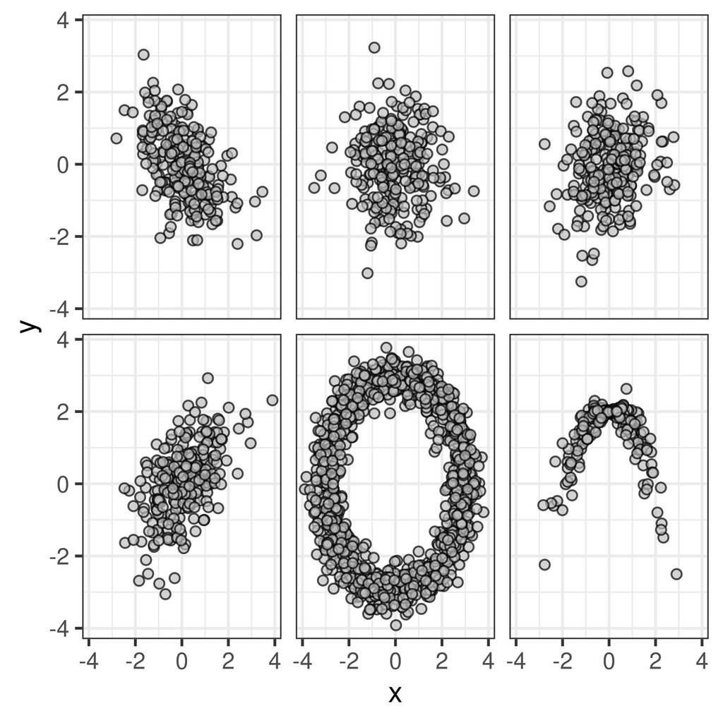

## Correlations

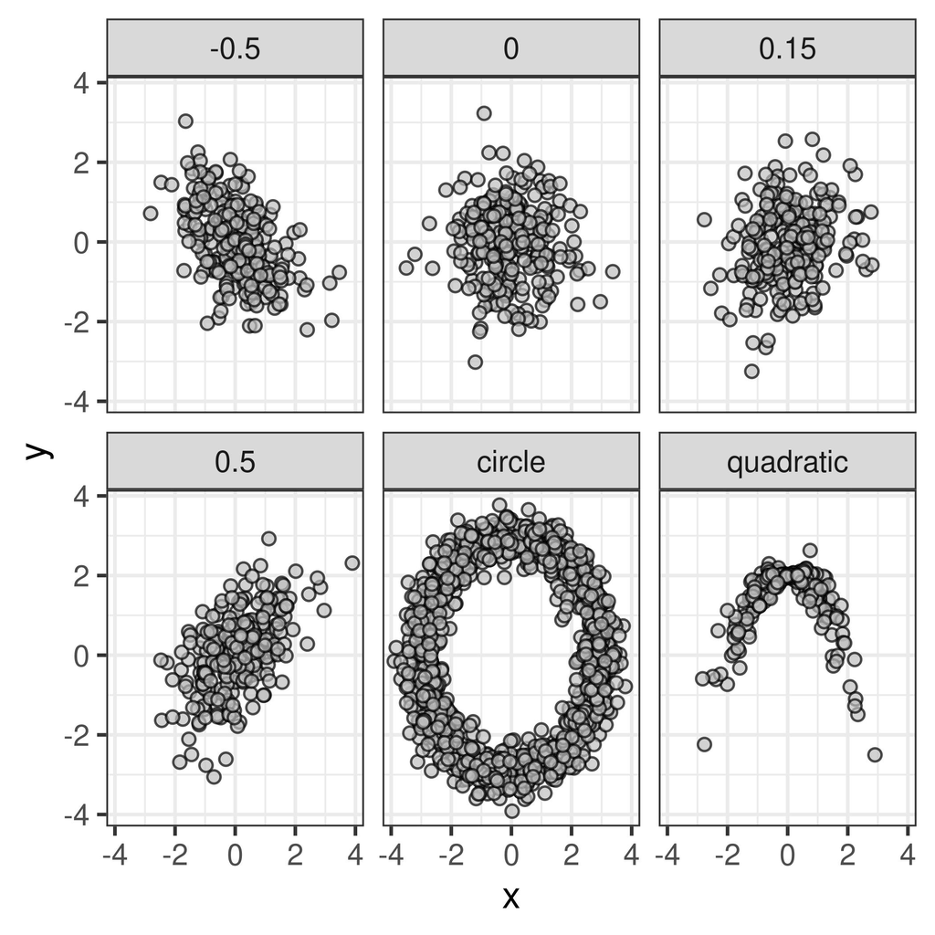

## Correlations

[figure not shown]

Correlation is not causation!

Source: [left](https://www.tylervigen.com/spurious/correlation/5950_popularity-of-the-first-name-lamont_correlates-with_burglary-rates-in-the-us) [right](https://www.tylervigen.com/spurious/correlation/4994_popularity-of-the-like-a-boss-meme_correlates-with_google-searches-for-how-to-cut-own-hair)

## Recap

You now know:

- The difference between methods and statistics
- The difference between the population and a sample
- The different measurement levels
- A few univariate and bivariate descriptives statistics